# Risk Factor Analysis

## Outcome Variable

**Outcome Variable:** haz

## Predictor Variables

**Intervention Variable:** feducyrs

**Adjustment Set:**

- arm
- W_mage
- meducyrs
- hhwealth_quart
- W_mhtcm
- W_mwtkg
- W_mbmi
- W_gagebrth
- W_birthwt
- W_birthlen
- single
- impsan
- delta_W_mage
- delta_meducyrs
- delta_hhwealth_quart
- delta_W_mhtcm
- delta_W_mwtkg
- delta_W_mbmi
- delta_W_gagebrth
- delta_W_birthwt
- delta_W_birthlen
- delta_single
- delta_impsan

## Stratifying Variables

The analysis was stratified on these variable(s):

- agecat

## Data Summary

| agecat | feducyrs | n_cell | n | outcome_variable |
| --- | --- | --- | --- | --- |
| Birth | High | 11195 | 60027 | haz |
| Birth | Low | 21206 | 60027 | haz |
| Birth | Medium | 27626 | 60027 | haz |
| 6 months | High | 12173 | 56620 | haz |
| 6 months | Low | 20048 | 56620 | haz |
| 6 months | Medium | 24399 | 56620 | haz |
| 24 months | High | 6447 | 26033 | haz |
| 24 months | Low | 9502 | 26033 | haz |
| 24 months | Medium | 10084 | 26033 | haz |

The following strata were considered:

- agecat: 24 months
- agecat: 6 months
- agecat: Birth

## Methods Detail

We’re interested in the causal parameters $E[Y_a]$ for all values of $a \in \mathcal{A}$. These parameters represent the mean outcome if, possibly contrary to fact, we intervened to set all units to have $A=a$. Under the randomization and positivity assumptions, these are identified by the statistical parameters $\psi_a=E_W[E_{Y|A,W}(Y|A=a,W)]$. In addition, we’re interested in the mean of $Y$, $E[Y]$ under no intervention (the observed mean). We will estimate these parameters by using SuperLearner to fit the relevant likelihood factors – $E_{Y|A,W}(Y|A=a,W)$ and $p(A=a|W)$, and then updating our likelihood fit using a joint TMLE.

For unadjusted analyses ($W=\{\}$), initial likelihoods were estimated using Lrnr_glm to estimate the simple $E(Y|A)$ and Lrnr_mean to estimate $p(A)$. For adjusted analyses, a small library containing Lrnr_glmnet, Lrnr_xgboost, and Lrnr_mean was used.

Having estimated these parameters, we will then use the delta method to estimate relative risks and attributable risks relative to a prespecified baseline level of $A$.

# Results Detail

## Results Plots

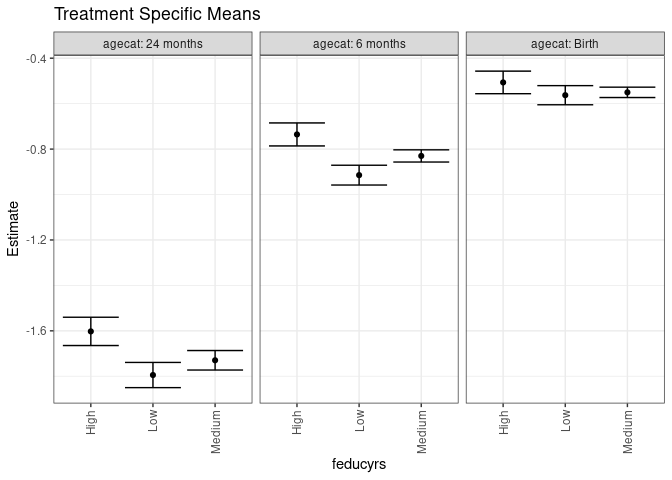

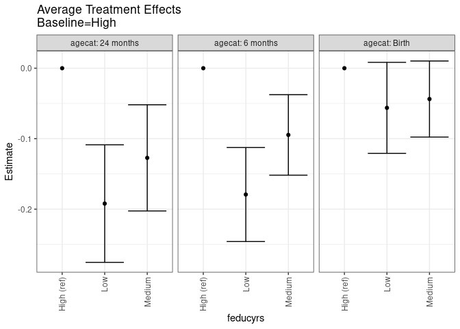

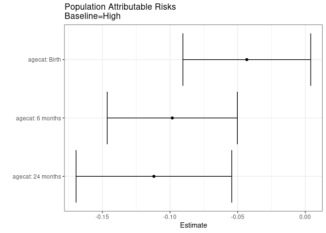

## Results Table

### Parameter: TSM

| agecat | intervention_level | baseline_level | estimate | ci_lower | ci_upper |
| --- | --- | --- | --- | --- | --- |
| Birth | High | NA | -0.5065865 | -0.5563007 | -0.4568723 |
| Birth | Low | NA | -0.5628085 | -0.6048672 | -0.5207498 |
| Birth | Medium | NA | -0.5503119 | -0.5730972 | -0.5275267 |
| 6 months | High | NA | -0.7355155 | -0.7861388 | -0.6848922 |
| 6 months | Low | NA | -0.9147290 | -0.9583292 | -0.8711287 |
| 6 months | Medium | NA | -0.8301726 | -0.8570943 | -0.8032510 |
| 24 months | High | NA | -1.6025340 | -1.6647892 | -1.5402787 |
| 24 months | Low | NA | -1.7946190 | -1.8501378 | -1.7391003 |
| 24 months | Medium | NA | -1.7297407 | -1.7726339 | -1.6868475 |

### Parameter: E(Y)

| agecat | intervention_level | baseline_level | estimate | ci_lower | ci_upper |
| --- | --- | --- | --- | --- | --- |
| Birth | NA | NA | -0.5498174 | -0.5660816 | -0.5335533 |
| 6 months | NA | NA | -0.8338469 | -0.8507377 | -0.8169561 |
| 24 months | NA | NA | -1.7144763 | -1.7390423 | -1.6899103 |

### Parameter: ATE

| agecat | intervention_level | baseline_level | estimate | ci_lower | ci_upper |
| --- | --- | --- | --- | --- | --- |
| Birth | High | High | 0.0000000 | 0.0000000 | 0.0000000 |
| Birth | Low | High | -0.0562219 | -0.1207588 | 0.0083149 |
| Birth | Medium | High | -0.0437254 | -0.0976825 | 0.0102317 |
| 6 months | High | High | 0.0000000 | 0.0000000 | 0.0000000 |
| 6 months | Low | High | -0.1792134 | -0.2458951 | -0.1125318 |
| 6 months | Medium | High | -0.0946571 | -0.1517663 | -0.0375479 |
| 24 months | High | High | 0.0000000 | 0.0000000 | 0.0000000 |
| 24 months | Low | High | -0.1920851 | -0.2754786 | -0.1086916 |
| 24 months | Medium | High | -0.1272067 | -0.2025352 | -0.0518783 |

### Parameter: PAR

| agecat | intervention_level | baseline_level | estimate | ci_lower | ci_upper |
| --- | --- | --- | --- | --- | --- |
| Birth | High | NA | -0.0432309 | -0.0904739 | 0.0040122 |
| 6 months | High | NA | -0.0983314 | -0.1464443 | -0.0502184 |
| 24 months | High | NA | -0.1119423 | -0.1694902 | -0.0543945 |